Applied Analytics · U.S. Elections · R + Quarto

# The Great Realignment: reading the 2024 electoral shift through data

A county-level analysis of how America voted differently in 2024 — and why the same numbers tell two very different stories depending on how you weight them.

Gerusa Maso · M.S. Business Analytics, Baruch College (CUNY) · Highlights edition

Maps can mislead. This project takes the 2024 county-level results and asks a harder question than "who won where" — it measures how much each county *moved*, tests whether the shift is real, and shows how the answer flips depending on whether you count land or people.

~3,100

U.S. counties analyzed (2020 → 2024)

89%

of counties shifted toward the GOP

2

opposing narratives tested against the same data

100%

reproducible R + Quarto pipeline

## 01The national picture

Joining Census Bureau county shapefiles to county-level returns produces the headline map: a near-uniform rightward shift across the country. Reproducing the well-known New York Times "arrow" figure makes the breadth of the movement immediately legible.

[figure not shown]

County-level partisan shift, 2020 → 2024 — a reproduction of the NYT arrow map.

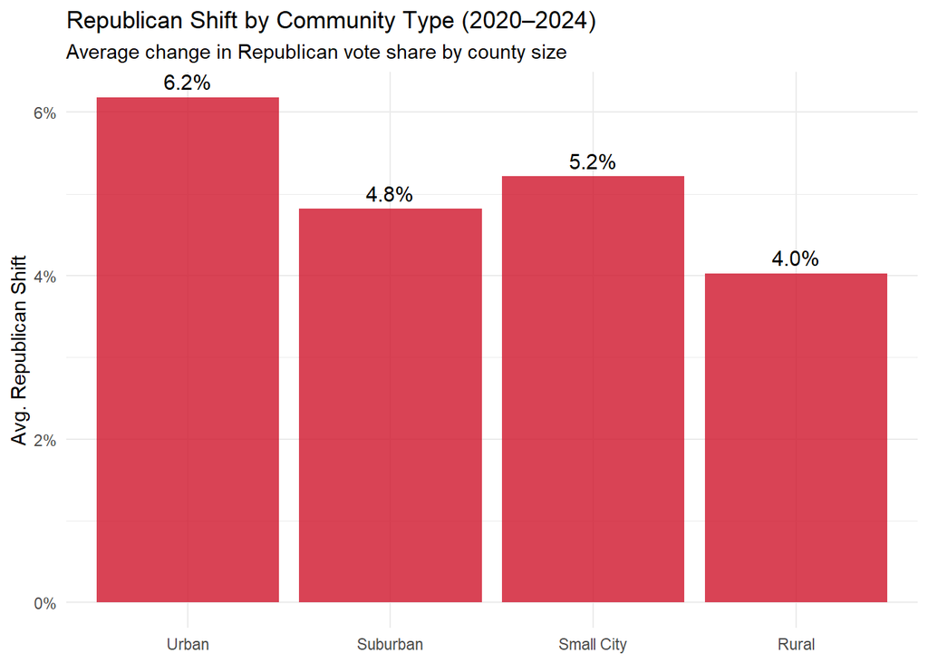

Mean partisan shift by community type. The movement appears across rural, suburban, and urban counties alike.

## 03The demographic story

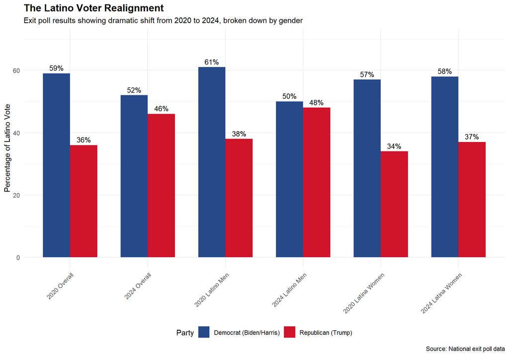

## 04The deepest divide is education

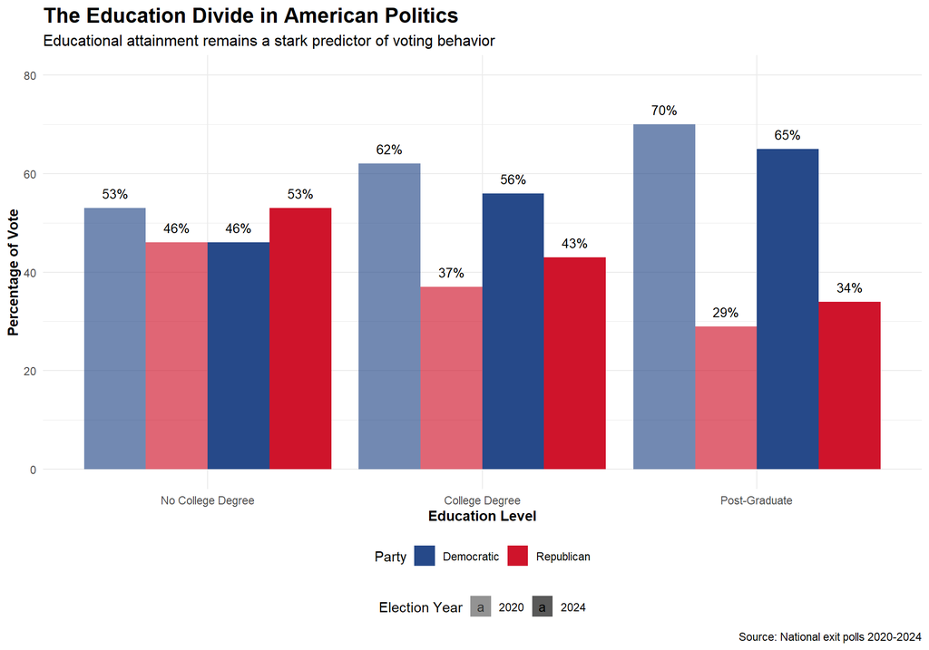

## 05Land doesn't vote — people do

Here is the analytical heart of the project. An unweighted county map overstates the shift, because most counties are small. Re-running the same data **population-weighted** shrinks the apparent realignment dramatically: the red map is real, but the red *mirage* is the gap between counties-that-moved and voters-who-moved.

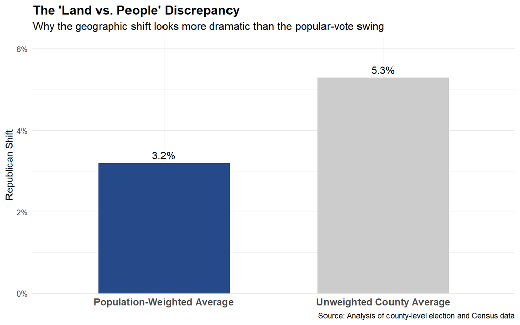

Unweighted vs population-weighted shift. Weighting by people, not counties, tells a more measured story.

## 06Where it actually mattered

Elections are decided in a handful of battleground counties. Isolating them shows the swing states barely moved relative to the national average — the broad shift was largest exactly where it changed the outcome least.

[figure not shown]

## What this demonstrates

Beyond the politics, the project is a study in analytical honesty: the same dataset supports a "historic landslide" reading and a "narrow, contained shift" reading, and only careful weighting, significance testing, and segmentation tell you which is fair. That discipline — pressure-testing a headline number before a stakeholder acts on it — is exactly the work of a business analyst.

> "The data doesn't change. The perspective does. Good analysis is knowing which framing the evidence actually supports."